# RNAseAlert kit test 02

Jan Sklenar

30/03/2020

# Test of the new kit, Cas13 background, and phosphate buffer

## Design

Is te new substrate working? WHat will be RFU numbers? How much we can affor to dilute the substrate for various tests? Is the signal stable after Cas13 addition? Is Phosphate buffer working? Does it interfere with fluorescence or DEPC?

#### Chemicals used in the reaction,

added in the following order in replicates of four, in squares on 96 well plate:

1. 20mM HEPES ph 7.0 buffer
2. Benzoase(TM)nuclease, 25U/ml stock solution
3. DEPC (inhibitor), 0.1% in the reaction
4. Imidazole (inhibitor quencher), 10mM in the reaction
5. Benzoase(TM)nuclease (fresh enzyme after the background has been inhibited)
6. Cas13 2mg/ml was diluted: 5ul/153ul in a buffer from Josie, which gives 10x concentrated. Here we test 100x concentrated as well, test tubes 3 and 4 respectively.
7. substrate (fluorescein-RNA conjugate), one tube designed for one test was used in all the test here - diluted in 28 replicates.

#### Test conditions (volumes in microliters per well)

[figure not shown]

Copy of original table in Excel.

## Data preparation

```r
## show cleaned data with selected columns
#' Well, Sample, SampleNo, RepNo, MeasTimeSec, RFU
df <- raw[,c(3,6,11,12,7,8)]
head(df)
```

```
##   Well Sample SampleNo RepNo MeasTimeSec      RFU
## 1  A05  1 1/4        1     1        0.00 0.210974
## 2  B05  1 2/4        1     2        0.25 0.210263
## 3  C05  2 1/4        2     1        0.50 0.561685
## 4  D05  2 2/4        2     2        0.75 0.479490
## 5  E05  3 1/4        3     1        1.00 0.245730
## 6  F05  3 2/4        3     2        1.25 0.241236
```

```r
str(df)
```

```
## 'data.frame':    432 obs. of  6 variables:
##  $ Well       : chr  " A05" " B05" " C05" " D05" ...
##  $ Sample     : chr  "1 1/4" "1 2/4" "2 1/4" "2 2/4" ...
##  $ SampleNo   : chr  "1" "1" "2" "2" ...
##  $ RepNo      : chr  "1" "2" "1" "2" ...
##  $ MeasTimeSec: num  0 0.25 0.5 0.75 1 1.25 1.5 1.75 2 2.25 ...
##  $ RFU        : num  0.211 0.21 0.562 0.479 0.246 ...
```

## Plots

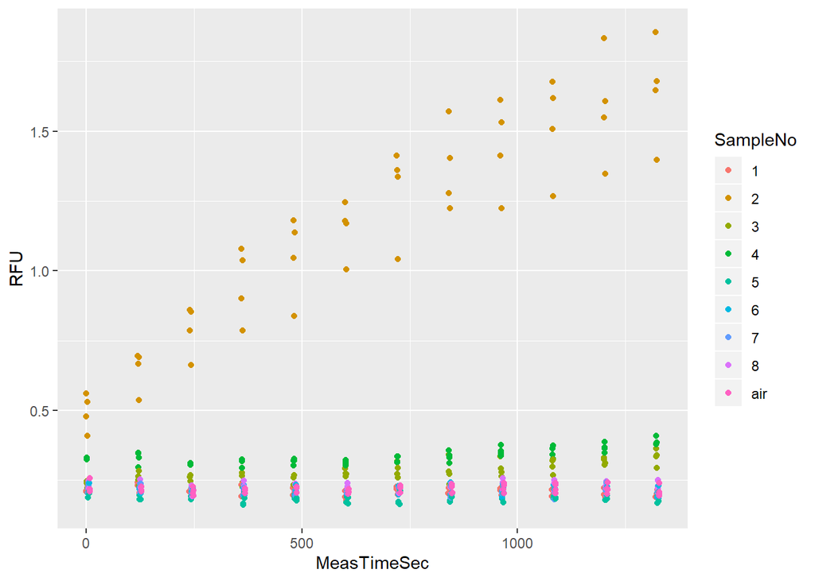

```r
#' all the data
#plot(x=raw$MeasTimeSec,y=raw$RFU)

#' colour labeled samples
ggplot(data = df) +
  aes(x = MeasTimeSec, y=RFU) +
  geom_point(aes(color=SampleNo))
```

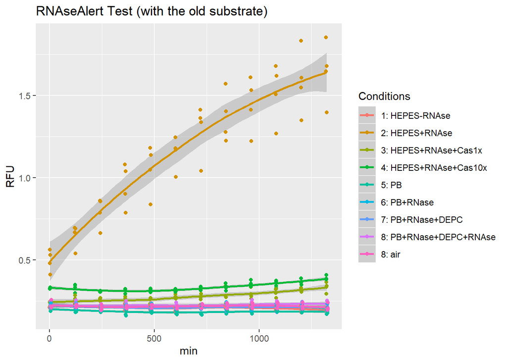

```r
# ## Use summary statistics (mean) to find and remove obvious  outlier in  sample 3
# #' means of all replicates of sample 3
# dfstat <- df %>% filter(SampleNo==1) %>% group_by(SampleNo,RepNo) %>% summarise(mean=mean(RFU))
# dfstat
# #' Data that should be removed
# filter(df,SampleNo == 3 & RepNo == 3)
# #' I could not invert the filter though
# #' But it is the same as leaving out all the measurement from the well E01
# dfs <- filter(df, Well != "E06")
# #' all the measurements
# length(rownames(df))
# #'after 12 datapoints were removed
# length(rownames(dfs))

## LOESS regression
p <- ggplot(data = df) +
  aes(x = MeasTimeSec, y=RFU) +
  geom_smooth(aes(color=SampleNo)) +
  geom_point(aes(colour=SampleNo))

  p + labs(title = "RNAseAlert Test (with the old substrate)", x = "min",   y = "RFU", color = "Legend Title\n") +
  #coord_cartesian(ylim = c(0,2)) +
  scale_colour_discrete(name="Conditions",
                      breaks=c(1,2,3,4,5,6,7,8,"air"),
                      labels=c("1: HEPES-RNAse",
                               "2: HEPES+RNAse",
                               "3: HEPES+RNAse+Cas1x",
                               "4: HEPES+RNAse+Cas10x",
                               "5: PB",
                               "6: PB+RNase",
                               "7: PB+RNase+DEPC",
                               "8: PB+RNase+DEPC+RNAse",
                               "8: air"))
```

## Conclutions

### Good:

- In this test the Substrate was 28 fold diluted, still producing a consistent signal

### Not very good:

- Cas13 supresses the signal significantly
- 10mM phosphate kills the signal completelly.

### What next:

- Use a bit more of the substrate.
- HEPES
- HEPES, DEPC
- test the buffer used to disolve Cas13
- if phosphate, try 20mM